# Evolutionary Models and ASR

Madison Bradley-Cronkwright (mmb103@duke.edu)

2024

### **Session Set-up**

When working in RStudio, it’s good practice to first clear the global environment and set a working directory.

```r
rm(list=ls(all=T)) # good practice to first clear workspace

# set working directory
## modify to pathway of the folder where your data is saved
setwd("C:/Users/mads/Desktop/Summer 2024/Doug's stats course materials/Markdowns/Evolutionary Models and ASR")
```

### **Install or Load packages**

Use install.packages() function if the package needs to be installed. If install.packages() fails, it may be easier to download packages according to instructions from their github.

It may also be helpful to open R session as an Administrator to prevent package installation issues.

```r
library(ggplot2)
library(ggthemes)
library(ggpmisc)
library(plyr)
library(ggrepel)
library(tidyverse)
library(ggtree)
library(ggstance)
library(paleotree)
library("geiger")
library("matrixStats")
library("MASS")
library("phytools")
library("OUwie")
library("corHMM")
library("diversitree")
library("phangorn")
library("adephylo")
library("reshape2")
library("boot")
library("car")
library("agricolae")
library("devtools")
library("btw")
library("coda")
library("pmc")
library(ape)
library(evobiR)
library(scales)
library(RRphylo)
library(mvMORPH)
library(cowplot)
```

### **Import Data**

Import data saved in the working directory in CSV format, then use the str() function to determine the structure of the dataset.

```r
# import data in CSV format (mine are saved with UTF-8-BOM encoding, but not all CSV files are encoded this way)
## modify to the name of your data sheet
d<-read.csv("C:/Users/mads/Desktop/Summer 2024/Doug's stats course materials/Markdowns/Evolutionary Models and ASR/ASR_variables_withgroups.csv",header = TRUE, stringsAsFactors = TRUE,fileEncoding = "UTF-8-BOM")

# good practice to check the structure of imported data
str(d)
```

```
  'data.frame': 117 obs. of  6 variables:
   $ Taxon        : Factor w/ 117 levels "Allenopithecus_nigroviridis",..: 1 23 24 28 34 56 57 59 60 63 ...
   $ hist_grouping: Factor w/ 10 levels "","ada","cerc",..: 3 3 3 3 3 3 3 3 3 3 ...
   $ ent_ast      : num  0.544 0.54 0.555 0.527 0.468 ...
   $ ectmes_ast   : num  0.854 0.87 0.957 0.867 0.902 ...
   $ ent_BM       : num  0.203 0.238 0.241 0.208 0.227 ...
   $ ectmes_BM    : num  0.321 0.383 0.416 0.342 0.44 ...
```

### **Import Phylogenetic Tree**

Tree is a consensus tree built in Mesquite from 10k Trees grafted with fossil taxa.

```r
# read tree in NEX format from wd into R environment
tree<-read.nexus("navicular_tree.nex")

# extract species from data
spp_obs <- as.character(d$Taxon)

# trim imported tree to the species in data
tree_trimmed <- keep.tip(tree,spp_obs)
```

### **Data Wrangling**

Many of the functions require named lists of numbers instead of data frames, so we have to make these.

```r
# reorder data frame by tip labels in the tree
reorder_d<-ReorderData(tree_trimmed,d,1) # number is the column with species names

# crop data sheet to species with values for all variables
c_reorder_d<-reorder_d[complete.cases(reorder_d),]
c_spp_obs<-as.character(c_reorder_d$Taxon)
# trim tree to species with values for all variables
c_tree_trimmed<-keep.tip(tree_trimmed,c_spp_obs)

# make data object for entocuneiform facet area/astragular facet area
ent_ast<-c_reorder_d[,"ent_ast"]
names(ent_ast)<-c_reorder_d$Taxon

# make data object for (ectocuneiform facet area+mesocuneiform)/astragular facet area
ectmes_ast<-c_reorder_d[,"ectmes_ast"]
names(ectmes_ast)<-c_reorder_d$Taxon
```

Before analysis, it is helpful to see the observed values of the ratio of entocuneiform facet area to astragalar facet area by taxonomic grouping.

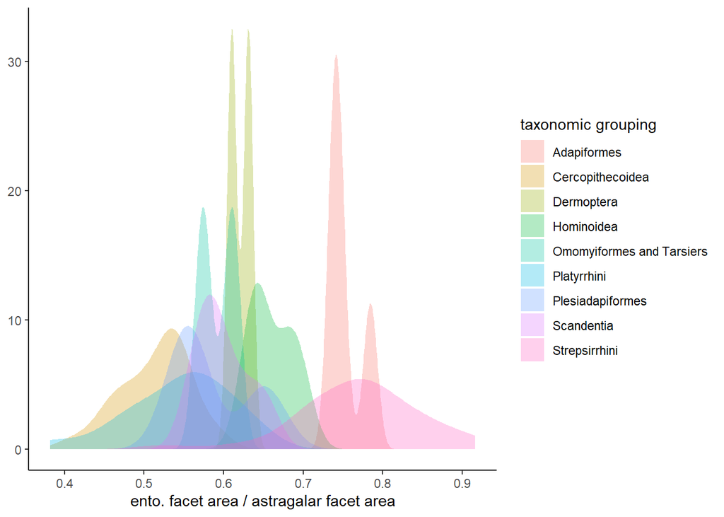

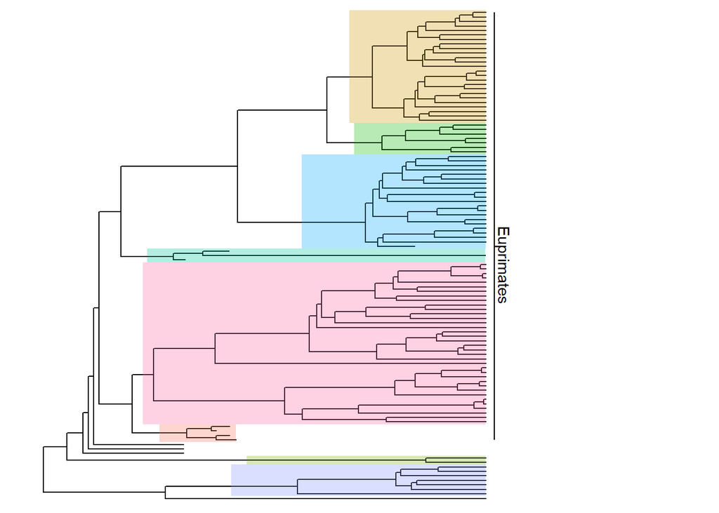

```r
#all
ggplot(c_reorder_d, aes(x=ent_ast, fill=hist_grouping)) +
 geom_density(alpha=.3,color=NA)+
  labs(fill="taxonomic grouping")+
  scale_fill_discrete(name = "taxonomic grouping",labels=c("Adapiformes", "Cercopithecoidea","Dermoptera","Hominoidea","Omomyiformes and Tarsiers","Platyrrhini","Plesiadapiformes","Scandentia","Strepsirrhini"))+
  labs(x="ento. facet area / astragalar facet area")+
  labs(y=NULL)+
  theme_classic()

ggtree(c_tree_trimmed)+
  geom_hilight(node=172, fill="#F87662", alpha=.3)+
  geom_hilight(node=119, fill="#CD9600", alpha=.3)+
  geom_hilight(node=210, fill="#7CAE00", alpha=.3)+
  geom_hilight(node=143, fill="#0CB702", alpha=.3)+
  geom_hilight(node=169, fill="#00C19A", alpha=.3)+
  geom_hilight(node=149, fill="#00A9FF", alpha=.3)+
  geom_hilight(node=212, fill="#8494FF", alpha=.3)+
  geom_hilight(node=175, fill="#FF68A1", alpha=.3)+
  geom_cladelab(node = 115,label="Euprimates",textcolor='black',barcolor='black',angle=270,offset.text=1)+
  xlim(0,120)
```

Next, it will be useful to plot the phylogenetic tree with tip labels and node numbers, and save a PDF of the labelled tree to the working directory for reference during node-specific analyses and commands.

```r
ggtree(c_tree_trimmed)+
  geom_text(aes(label=node), hjust=0,size=2)+
  geom_tiplab(hjust=-.25,size=2.5)+
  xlim(0,120)
# save pdf of tree to wd
ggsave("node_label.pdf", width = 8, height = 15, units = "in", limitsize = FALSE)
```

### **Ancestral State Reconstruction using fastAnc function**

Estimates ancestral states for a continuous character under maximum likelihood (choses the parameters of a statistical model to provide the most probable description of the observed data). The function reroots the tree at all internal nodes and computes the contrasts state at the root each time.  
The output is a list (names are node numbers) with the reconstructed values at internal nodes (ace), variances on the estimates (var), and/or 95-percent confidence intervals (CI95).

```r
# Ancestral Character Estimates using fastAnc() which produces an object with estimated values at ancestral nodes with 95% CI
anc_ent_ast<-fastAnc(c_tree_trimmed,ent_ast,var=TRUE,CI=TRUE) # Entocuneiform facet area as a ratio of astragalar facet area
print(anc_ent_ast) # shows list of ace numbered by node and a list of 95% CI of each estimate numbered by node
```

```
Ancestral character estimates using fastAnc:
     110      111      112      113      114      115
0.614369 0.617570 0.619576 0.618564 0.621360 0.627744
     116      117      118      119      120      121
0.616698 0.580747 0.578670 0.535818 0.527833 0.525534
     122      123      124      125      126      127
0.524600 0.522538 0.517020 0.518441 0.526922 0.525981
     128      129      130      131      132      133
0.515483 0.510452 0.521037 0.527661 0.513309 0.505220
     134      135      136      137      138      139
0.494692 0.511211 0.510162 0.518331 0.564097 0.503954
     140      141      142      143      144      145
0.505748 0.519686 0.467304 0.629239 0.657400 0.641319
     146      147      148      149      150      151
0.659885 0.672717 0.639457 0.544424 0.544142 0.552453
```

[output cut: 171 more lines]

If wanted, code to export the fastAnc output as a csv within the working directory.

```r
# Export output as CSV to WD
lapply(anc_ent_ast, function(x) write.table(data.frame(x), 'MLanc_ent_ast.csv',append=T,sep=','))# might trigger a warning
```

### **Visualizing Ancestral State Reconstruction for a Continuous Trait**

This is a method that is a quick, easy way to plot the ASR of a continuous trait throughout a phylogeny. Under the hood, the continuous mapping function is using the fastAnc method from the previous chunk.

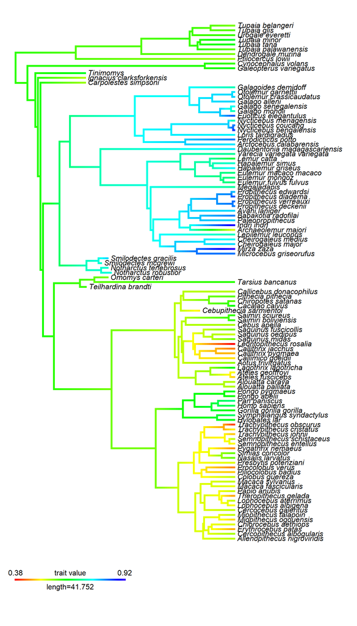

```r
# make object that projects the reconstruction onto the edges of the tree
map.obj<-contMap(c_tree_trimmed,ent_ast,plot = FALSE)

# plot ASR of the ratio of entocuneiform facet area to astragalar facet area
plot(map.obj,type="phylogram",sig=2,outline=FALSE) # to 2 significant digits
```

### **Ancestral State Reconstruction using anc.Bayes function**

Uses Bayesian MCMC to sample from the posterior distribution for the states at internal nodes in the tree.

Can assign a starting value for the BM rate as a prior, but this is’t required.

Can assign a value for the root and/or specific nodes as a prior, but this isn’t required.

After running the ASR (which takes some time), the output can be saved to the working directory as an RDS file and imported during later sessions. Having saved the RDS will prevent always needing to run the ASR MCMC and also helps with reproducibility.

```r
set.seed(23)
# run MCMC; should use at least 1e6 generations
ace_ent_ast<-anc.Bayes(c_tree_trimmed,ent_ast,ngen=1e6)

# save MCMC output to the wd as an RDS file
saveRDS(ace_ent_ast, "ace_ent_ast.rds")
```

```r
# load in Bayes models after they've been ran and saved
ace_ent_ast <- readRDS("ace_ent_ast.rds")

# returns vector of estimated ancestral states with default burn-in of 20% of MCMC generations
summary(ace_ent_ast)
```

```
Object of class "anc.Bayes" consisting of a posterior
   sample from a Bayesian ancestral state analysis:

Mean ancestral states from posterior distribution:
     110      111      112      113      114      115
0.615511 0.615314 0.615439 0.614207 0.617979 0.624585
     116      117      118      119      120      121
0.612475 0.572417 0.573972 0.534485 0.529480 0.527864
     122      123      124      125      126      127
0.526995 0.523937 0.518706 0.520785 0.528476 0.525684
     128      129      130      131      132      133
0.513142 0.508565 0.520256 0.528561 0.510705 0.505818
     134      135      136      137      138      139
0.497062 0.505916 0.504460 0.513614 0.561406 0.498064
     140      141      142      143      144      145
0.504830 0.519501 0.466202 0.625088 0.656741 0.636887
     146      147      148      149      150      151
0.657991 0.669743 0.638271 0.544325 0.543561 0.553904
     152      153      154      155      156      157
0.551636 0.559354 0.503292 0.541551 0.537876 0.510583
     158      159      160      161      162      163
0.501269 0.493717 0.469929 0.535652 0.547922 0.547552
     164      165      166      167      168      169
0.606834 0.541789 0.546179 0.584434 0.609874 0.604137
     170      171      172      173      174      175
0.586792 0.680545 0.729721 0.740683 0.745706 0.700370
     176      177      178      179      180      181
0.727844 0.748637 0.752424 0.757808 0.765821 0.795785
     182      183      184      185      186      187
0.840837 0.780824 0.770690 0.753448 0.787747 0.793944
     188      189      190      191      192      193
0.790945 0.819730 0.832006 0.824002 0.719956 0.714537
     194      195      196      197      198      199
0.701504 0.700924 0.714758 0.721547 0.758321 0.766009
     200      201      202      203      204      205
0.786832 0.771474 0.785030 0.840167 0.765776 0.774455
     206      207      208      209      210      211
0.788223 0.749029 0.778544 0.781580 0.619731 0.601561
     212      213      214      215      216      217
0.597348 0.607171 0.614584 0.619209 0.605616 0.592870

Based on a burn-in of 2e+05 generations.
```

### **Investigate and Plot Posterior Distribution of Ancestral Character Estimates for Specific Nodes**

The PDF “node_label” was exported to the wd in an earlier chunk and now it can be used for reference when determining which nodes to examine.

Some nodes of interest are:

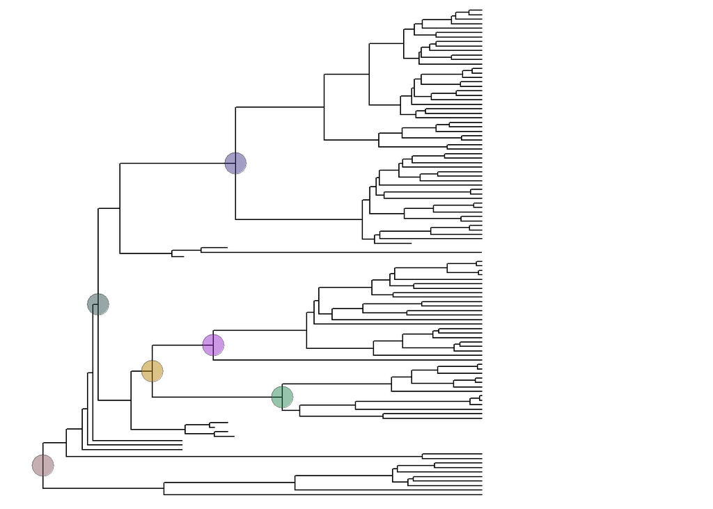

| Node | Description | Color |
| --- | --- | --- |
| 110 | Root of Tree | Light Pink |
| 115 | Base of Euprimates | Dark Green |
| 117 | Base of Anthropoidea | Purple |
| 175 | Base of modern Strepsirrhines | Yellow |
| 176 | Base of Lemuriformes | Magenta |
| 198 | Base of Lorisiformes | Light Green |

The base R function, density(), can be used to make a object that describes the posterior distribution of the ASR by the anc.Bayes MCMC.

For example, here is the posterior of the estimates of the ancestral state at node 115.

```r
# compare posterior density of the estimates of entocuneiform facet area / astragular facet area at specific nodes of interest

# 115
dens_115<-density(ace_ent_ast,what=115,burnin=20000) # number of node indicated with the "what=" command
dens_115 # information about the posterior distribution
```

```
Call:
    density.anc.Bayes(x = ace_ent_ast, what = 115, burnin = 20000)

Data: node 115 (9801 obs.); Bandwidth 'bw' = 0.004724

       x                y
 Min.   :0.4981   Min.   : 0.0001
 1st Qu.:0.5612   1st Qu.: 0.2058
 Median :0.6242   Median : 2.0207
 Mean   :0.6242   Mean   : 3.9627
 3rd Qu.:0.6872   3rd Qu.: 8.0083
 Max.   :0.7502   Max.   :11.5800
```

The object describing the posterior density of ancestral state estimates at single nodes can also be passed to plotting functions.

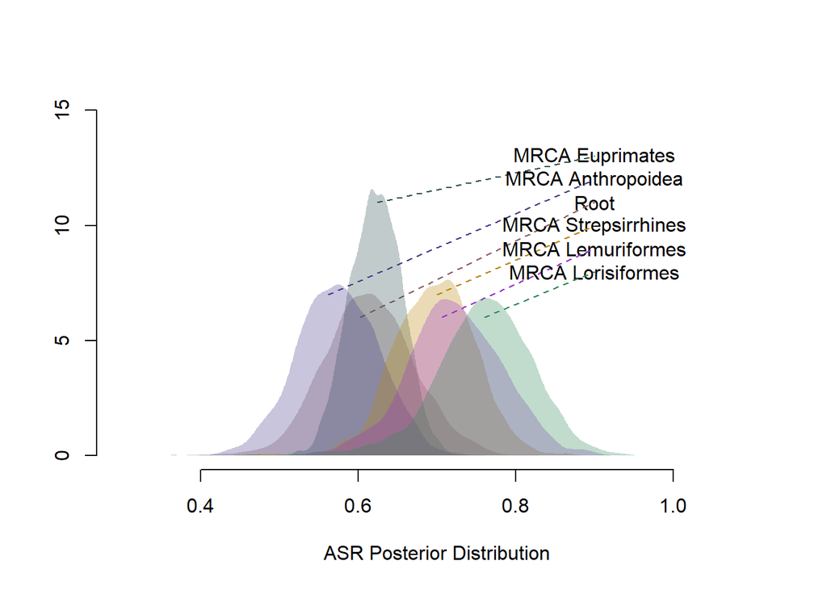

```r
plot(NULL,frame=FALSE,xlim=c(0.30,1.1),ylim=c(0,15),ylab="",xlab="ASR Posterior Distribution") #make empty plot to fill with posterior densities
polygon(dens_110, col = alpha("lightpink4",0.3),border=FALSE)
text(x=.9,y=11,labels="Root",col="black")
lines(x=c(mean(dens_110$x),.9),y=c(6,11),col="lightpink4",lty=2)
polygon(dens_115, col = alpha("darkslategray",0.3),border=FALSE)
text(x=.9,y=13,labels="MRCA Euprimates")
lines(x=c(mean(dens_115$x),.9),y=c(11,13),col="darkslategray",lty=2)
polygon(dens_117, col = alpha("darkslateblue",0.3),border=FALSE)
text(x=.9,y=12,labels="MRCA Anthropoidea")
lines(x=c(mean(dens_117$x),.9),y=c(7,12),col="darkslateblue",lty=2)
polygon(dens_175,col = alpha("darkgoldenrod",0.3),border=FALSE)
text(x=.9,y=10,labels="MRCA Strepsirrhines")
lines(x=c(.7,.9),y=c(7,10),col="darkgoldenrod",lty=2)
polygon(dens_176,col = alpha("darkorchid",0.3),border=FALSE)
text(x=.9,y=9,labels="MRCA Lemuriformes")
lines(x=c(mean(dens_176$x),.9),y=c(6,9),col="darkorchid",lty=2)
polygon(dens_198,col = alpha("seagreen",0.3),border=FALSE)
text(x=.9,y=8,labels="MRCA Lorisiformes")
lines(x=c(.76,.9),y=c(6,8),col="seagreen",lty=2)
```

### **Phylogenetic Signal of a Trait Using phylosig function**

The phylosig function calculates the phylogenetic signal of a trait using two different, user-specified methods:

This function can also indicate whether a phylogenetic signal by either method is significant (p<0.05).

**1. Pagel’s $\lambda$ Method**

Output is $\lambda$ value and the p-value of the estimated phylogenetic signal tested against null hypothesis.

$\lambda$ values range between 0 and the thereotical upper limit of $\lambda$ determined by the relative height of the most recent internal node.

```r
# Pagel's Method
y_lambda<-phylosig(c_tree_trimmed,ectmes_ast,method="lambda",test=TRUE)
# Returns lambda and P-value against null hypothesis
print(y_lambda)
```

```
Phylogenetic signal lambda : 0.91643
logL(lambda) : 167.925
LR(lambda=0) : 70.1842
P-value (based on LR test) : 5.40184e-17
```

The returned phylosig object can then be used to visualize the $\lambda$ likelihood surface.

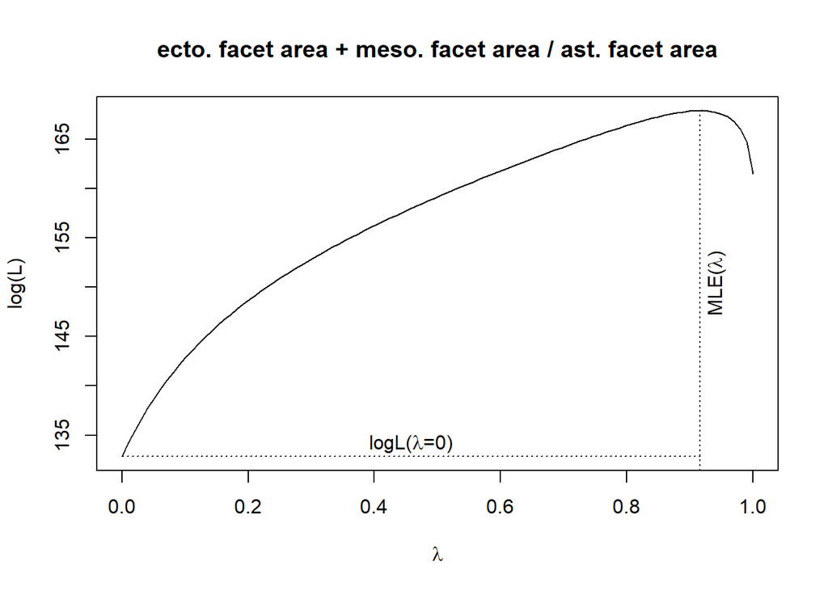

```r
# Plots likelihood surface
plot(y_lambda)
title(main="ecto. facet area + meso. facet area / ast. facet area")
```

**2. Bloomberg’s K Method**

Output is K and p-value of K against null hypothesis.

```r
# Bloomberg et al.'s Method
y_K<-phylosig(c_tree_trimmed,ectmes_ast,method="K",test=TRUE)
# Returns K and P-value of test against null hypothesis
print(y_K)
```

```
Phylogenetic signal K : 0.415063
P-value (based on 1000 randomizations) : 0.001
```

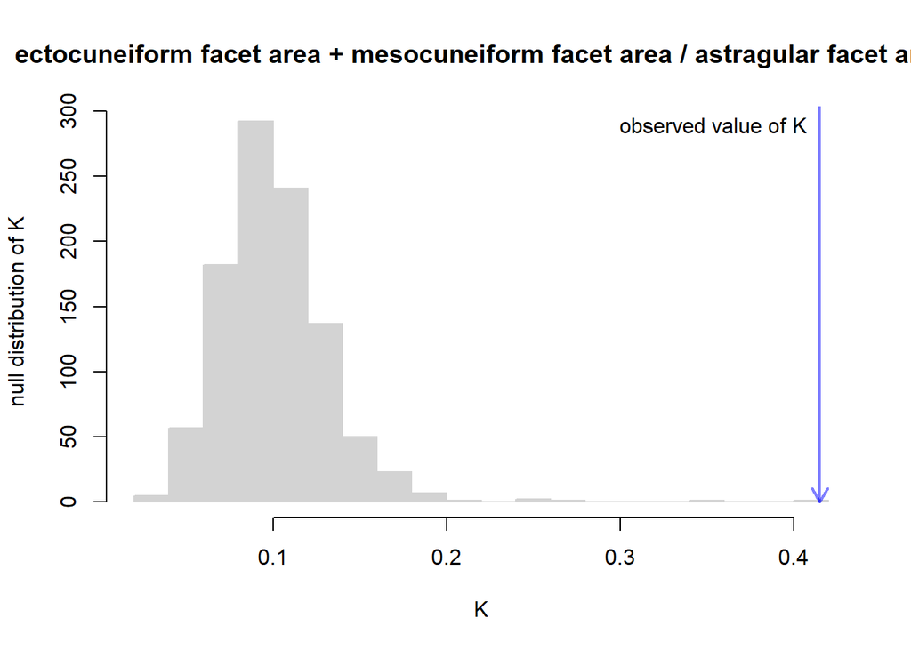

```r
# Using returned phylosig obj to plot observed value of K and the null distribution of K
plot(y_K)
title(main="ectocuneiform facet area + mesocuneiform facet area / astragular facet area")
```

### **Test for an Evolutionary Trend Using phytools ACE Model Comparison**

This method only tests across the entire tree.This method relies on phytools, the package that been used for most of the analyses so far. However, models may not converge, so this method should be used with caution.

```r
# ent_ast

# fit with no trend model
fit.bm.entast<-anc.ML(c_tree_trimmed,ent_ast,model="BM")

# fit with trend model
fit.trend.entast<-anc.trend(c_tree_trimmed,ent_ast) # Note that this will generally only work and produce sensible results for a phylogeny with some  fossil species

# compare trend vs no trend models and estimates
AIC(fit.bm.entast,fit.trend.entast)
```

```
                  df       AIC
fit.bm.entast    109 -674.9828
fit.trend.entast 110 2934.5659
```

```r
# fit with no trend model
fit.bm.ectmesast<-anc.ML(c_tree_trimmed,ectmes_ast,model="BM")

# fit with trend model
fit.trend.ectmesast<-anc.trend(c_tree_trimmed,ectmes_ast)


# compare trend vs no trend models and estimates
AIC(fit.bm.ectmesast,fit.trend.ectmesast)
```

[output not shown]

### **Test for Trends in Rate and Phenotypic Change using Phylogenetic Ridge Regression**

Unlike other Phylogenetic Comparative Methods, RRPhylo can test for trends across the entire tree and within specific lineages. Analyses can be informed with fossil taxa.

To search for temporal trends in phenotypes and absolute rates, the function computes regression slopes between values at nodes and tips and their distance from the root. Absolute rates are rescaled from 0-1 and logged. Significance is determed by comparing the real slope to a family of 100 slopes generated by simulating phenotypes under Brownian Motion.

```r
# whole tree
RR<-RRphylo(tree=c_tree_trimmed,y=ent_ast)
search.trend(RR=RR,y=ent_ast)
```

```r
# At specific nodes (base of Euprimates = 115, base of Strepsirrhines = 175)
search.trend(RR=RR,y=ent_ast,node = c(115,175))
```

```
[1] "Absolute evolutionary rates increase slower than BM expectation"
[1] "Absolute evolutionary rates regression slope through node 175 is higher than for the rest of the tree"
[1] "Phenotypic regression through node 115 is lower than regression through node 175"
[1] "Absolute evolutionary rates regression slope through node 115 is lowerthan regression through node 175"
```

```
$trend.data
List of 3 outputs
$phenotypic.regression
          slope    p.real p.random         dev
y -0.0008439252 0.2623302     0.27 -0.04925955

$rate.regression
          slope       p.real p.random   spread
rate 0.01773952 0.0007827463     0.02 2.911075

$node.phenotypic.regression
$node.phenotypic.regression$`115`
         slope p.slope emm.difference     p.emm
y -0.001491028    0.18     0.07445118 0.1176765

$node.phenotypic.regression$`175`
        slope p.slope emm.difference        p.emm
y 0.001788813    0.97      0.3898489 1.696784e-57


$node.rate.regression
$node.rate.regression$`115`
     emm.difference     p.emm  slope.node slope.others
rate    0.002543781 0.2383171 0.000106852 2.941097e-06
      p.slope
rate 0.170477

$node.rate.regression$`175`
     emm.difference       p.emm   slope.node slope.others
rate     0.00423361 0.003104665 0.0002910973 3.013288e-05
         p.slope
rate 0.005059017


$group.comparison
$group.comparison$phenotype
     group_1 group_2 slope.group_1 slope.group_2 p.slope
g115    g115    g175  -0.001491028   0.001788813    0.01
     emm.difference        p.emm
g115       -0.39902 1.221245e-14

$group.comparison$rate
  group_1 group_2 emm.difference      p.emm slope.group1
1    g115    g175    -0.00405601 0.01594883 3.188096e-05
  slope.group2    p.slope
1 0.0002910973 0.02353956


$ConfInts
List of 3 outputs
```

**Example RRphylo plots for node 175**

First, make an object to be passed to plotting functions for a node of interest. Here, node 175 is the base of Strepsirrhines.

```r
plotST175<-plotTrend(search.trend(RR=RR,y=ent_ast,node = 175))
```

Plot the phenotypic change through time (*left*), and the rate of evolutionary change through time (*right*) of the ratio of entocuneiform facet area to astragular facet area. These plots compare the actual values for the whole tree against the expectations of change according to brownian motion.

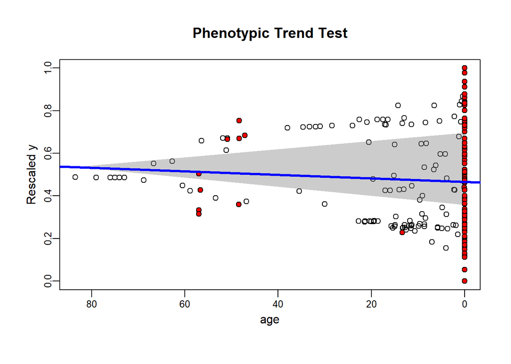

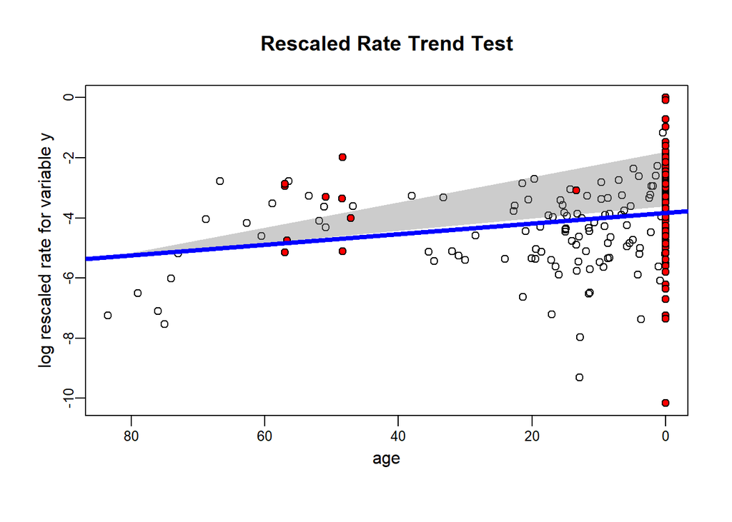

```r
plotST175$plotPhen(1) # to plot phenotypic trend through time for entire tree
plotST175$plotRates(1) # to plot rates trend through time for entire tree
```

Plot the phenotypic change through time (*left*), and the rate of evolutionary change through time (*right*) of the ratio of entocuneiform facet area to astragular facet area. These plots compare the clade descended from node 175 against the rest of the tree.

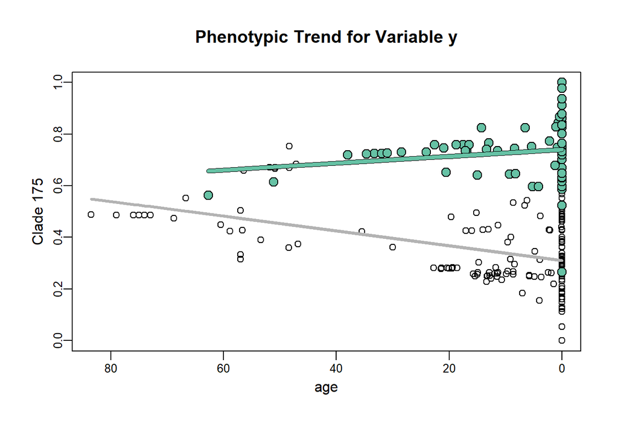

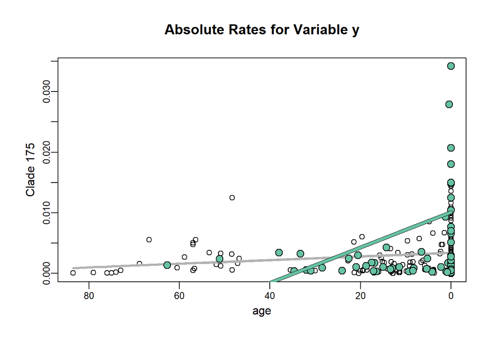

```r
plotST175$plotPhenNode("y") # to plot phenotypic trend through time for the clade
plotST175$plotRatesNode("y") # to plot rates trend through time for the clade
```

### **Multivariate Evolutionary Model Comparison using mvMORPH**

Fit different evolutionary models to data across the entire tree using the functions from mvMORPH package.

The models are then compared using Akaike Information Criterion (AIC) weights.

**Fit Brownian Motion Model with No Trend**

```r
# Brownian Motion with no trend
fit_bm<-mvBM(c_tree_trimmed,ent_ast,model = "BM1",diagnostic = F)
```

**Fit Brownian Motion Model with Trend**

Note: according to mvMORPH documentation, a trend can be estimated reliably only on non-ultrametric trees, so first check the tree if you’re not sure.

```r
is.ultrametric(c_tree_trimmed) # according to mvMORPH documentation, a trend can be estimated reliably only on non-ultrametric trees.
```

[output not shown]

```r
# Brownian Motion with trend
fit_bm_t<-mvBM(c_tree_trimmed,ent_ast,param=list(trend=TRUE),model = "BM1",diagnostic = F)
```

**Fit Early Burst Model (Harmon et al. 2010)**

```r
# Fit Early Burst Model (Harmon et al. 2010)
fit_EB<-mvEB(c_tree_trimmed,ent_ast,method="sparse")
```

**Fit Model According to Ornstein-Uhlenbeck Process with unique selective regime for the whole tree**

```r
# Fit model according to Ornstein-Uhlenbeck process with unique selective regime for the whole tree
fit_OU<-mvOU(c_tree_trimmed,ent_ast,model="OU1",method="sparse")
```

**Compare Evolutionary Models using AICc**

AICc is Aaike Information Criterion with a correction for small sample sizes.

```r
# Compare AIC
results<-c(AIC(fit_bm),AIC(fit_bm_t),AIC(fit_EB),AIC(fit_OU))
aicw(results,aicc=TRUE) # AICc is AIC with correction for small sample sizes
```

```
-- Akaike weights --
  Rank  AIC  diff      wi    AICw
4    1 -257  0.00 1.00000 0.97228
1    2 -249  8.21 0.01651 0.01605
3    3 -247 10.21 0.00607 0.00590
2    4 -247 10.26 0.00593 0.00576
```

### **References**

*10k Trees website*:

https://10ktrees.nunn-lab.org/

Arnold C, Matthews LJ, Nunn CL. (2010) The 10kTrees website: a new online resource for primate phylogeny. Evolutionary Anthropology: Issues, News, and Reviews 19(3): 114-118.

*Mesquite github*:  
https://github.com/MesquiteProject/MesquiteCore/releases

*Phytools github*:  
https://github.com/liamrevell/phytools

*Phytools R Documentation*:  
https://cran.r-project.org/web/packages/phytools/phytools.pdf

*Phytools Original Paper*:  
Revell LJ (2012). “phytools: An R package for phylogenetic comparative biology (and other things).” Methods in Ecology and Evolution 3: 217-223.

*Phytools Vignette*:  
http://www.phytools.org/Bariloche2016/ex/10/Anc-states-continuous.html

*Phylogenetic Signal Papers*:  
Pagel M (1999) Inferring the historical patterns of biological evolution. Nature 401: 877-884.

Blomberg SP, Garland T Jr, Ives AR (2003) Testing for phylogenetic signal in comparative data: Behavioral traits are more labile. Evolution 57: 717-745.

Harmon LJ, Losos JB, Davies JT, Gillespie RG, Gittleman JL, Jennings BW, Kozak KH, McPeek MA, Moreno-Roark F, Near TJ, Purvis A, Ricklefs RE, Schluter D, Schulte II JA, Seehausen O, Sidlauskas BL, Torres-Carvajal O, Weir JT, Mooers AO (2010) Early bursts of body size and shape evolution are rare in comparative data. Evolution 64: 2385-2396.

*RRPhylo Citations*: https://cran.r-project.org/web/packages/RRphylo/citation.html

*RRPhylo search.trend vignette*:  
https://cran.r-project.org/web/packages/RRphylo/vignettes/search.trend.html

*mvMORPH github*:  
https://github.com/JClavel/mvMORPH

*mvMORPH documentation and vignettes*:  
chrome-extension://efaidnbmnnnibpcajpcglclefindmkaj/https://cran.r-project.org/web/packages/mvMORPH/mvMORPH.pdf

chrome-extension://efaidnbmnnnibpcajpcglclefindmkaj/https://cran.r-project.org/web/packages/mvMORPH/vignettes/How_to_use_mvMORPH.pdf

chrome-extension://efaidnbmnnnibpcajpcglclefindmkaj/https://cran.r-project.org/web/packages/mvMORPH/vignettes/tutorial_mvMORPH.pdf

https://www.nature.com/articles/s41467-019-13026-3#Sec8

*mapping data to trees vignette*:https://yulab-smu.top/treedata-book/chapter7.html

OS: Windows 10 x64 OS Build: 22631.3737 R Version: 4.1.1 Platform: x86_64-w64-mingw32/x64 (64-bit)